# Assignment 1

Regression Models

Javier Fong 100437994

1. Show that the properties of least squares estimators are satisfied using the following definitions.

$$\hat{\beta} = (X^{T}X)^{-1}X^{T}Y$$
$$\hat{Y} = X\hat{\beta}
= X(X^{T}X)^{-1}X^{T}Y = HY$$
$$\hat{\varepsilon} = Y - \hat{Y} = (I - H) Y$$

Important notes:

Given that $H$ is symmetric, then
$$H = H^{T}$$
and,
$$HH = (X(X^{T}X)^{-1}X^{T})(X(X^{T}X)^{-1}X^{T})
= X(X^{T}X)^{-1}(X^{T}X)(X^{T}X)^{-1}X^{T} = X(X^{T}X)^{-1}X^{T} = H$$

Least Squares Properties

1. $1^{T}(I-H)Y = 0$
2. $1^{T}Y = 1^{T}\hat{Y}$
3. $X^{T}\hat{\varepsilon} = 0$
4. $\hat{Y}^{T}\hat{\varepsilon} = 0$

Demonstrations:

- $1^{T}(I-H)Y = 0$

Proof,
$$1^{T}(I-H)Y = (1^{T}I-1^{T}H)Y$$
$$1^{T}(I-H)Y = (1^{T}-1^{T})Y$$
$$1^{T}(I-H)Y = 0Y$$
$$1^{T}(I-H)Y = 0 \square$$
* $1^{T}Y = 1^{T}\hat{Y}$

Proof,

$$1^{T}\hat{Y} = 1^{T}HY$$
$$1^{T}\hat{Y} = (H^{T}1)^{T}Y$$
$$1^{T}\hat{Y} = (H1)^{T}Y$$
$$1^{T}\hat{Y} = 1^{T}Y \square$$

- $X^{T}\hat{\varepsilon} = 0$

Proof,

$$X^{T}\hat{\varepsilon} = X^{T}(Y -
\hat{Y})$$
$$X^{T}\hat{\varepsilon} =
X^{T}(Y - HY)$$
$$X^{T}\hat{\varepsilon} = X^{T}Y - X^{T}HY$$
$$X^{T}\hat{\varepsilon} = X^{T}Y -
X^{T}X(X^{T}X)^{-1}X^{T}Y$$
$$X^{T}\hat{\varepsilon} = X^{T}Y - X^{T}Y$$
$$X^{T}\hat{\varepsilon} = 0 \square$$

- $\hat{Y}^{T}\hat{\varepsilon} = 0$

Proof,

$$\hat{Y}^{T}\hat{\varepsilon} =
(HY)^{T}(I - H)Y$$
$$\hat{Y}^{T}\hat{\varepsilon} = Y^{T}H(Y -
HY)$$
$$\hat{Y}^{T}\hat{\varepsilon} =
Y^{T}HY - Y^{T}HHY$$
$$\hat{Y}^{T}\hat{\varepsilon} = Y^{T}HY -
Y^{T}HY$$
$$\hat{Y}^{T}\hat{\varepsilon} =
0\square$$

2. Using the model *modall*, check numerically that the properties of the least squares estimates are satisfied.

```r
bodyfat = read.csv("../Datasets/bodyfat.txt", sep = "")
modall = lm (
  hwfat ~ .
  , bodyfat
)
summary(modall)
```

```
##
## Call:
## lm(formula = hwfat ~ ., data = bodyfat)
##
## Residuals:
##    Min     1Q Median     3Q    Max
## -6.162 -1.858 -0.464  2.502  8.177
##
## Coefficients:
##             Estimate Std. Error t value Pr(>|t|)
## (Intercept) 13.29370    9.63027   1.380   0.1718
## age         -0.32893    0.32158  -1.023   0.3098
## ht          -0.06731    0.16051  -0.419   0.6762
## wt          -0.01365    0.02591  -0.527   0.5999
## abs          0.37142    0.08837   4.203 7.55e-05 ***
## triceps      0.38743    0.13761   2.815   0.0063 **
## subscap      0.11405    0.14193   0.804   0.4243
## ---
## Signif. codes:  0 '***' 0.001 '**' 0.01 '*' 0.05 '.' 0.1 ' ' 1
##
## Residual standard error: 3.028 on 71 degrees of freedom
## Multiple R-squared:  0.8918, Adjusted R-squared:  0.8827
## F-statistic: 97.54 on 6 and 71 DF,  p-value: < 2.2e-16
```

- Sum of residuals is 0:

```r
modall$residuals %>%
  sum() %>%
  round(10)
```

```
## [1] 0
```

- Sum of the observed data is equal to the sum of the fitted values:

```r
modall$fitted.values %>% sum()
```

```
## [1] 1110.35
```

```r
bodyfat$hwfat %>% sum()
```

```
## [1] 1110.35
```

- The residuals are orthogonal to the predictors:

```r
(bodyfat[,-7] * modall$residuals) %>%
  sum() %>%
  round(10)
```

```
## [1] 0
```

- The residuals are orthogonal to the fitted values:

```r
(modall$residuals * modall$fitted.values) %>%
  sum() %>%
  round(10)
```

```
## [1] 0
```

3. Check that for the data set *index.txt*, the least squares estimates of the parameters are: $\hat\beta_{o}=4.267$ and $\hat\beta_{1}=1.373$, using the results in section 2.4.1 (not using the lm() function).

```r
indexdata = read.csv("../Datasets/index.txt", sep = "\t")
beta_one = cov(indexdata$PovPct, indexdata$Brth15to17)/var(indexdata$PovPct)
beta_zero = mean(indexdata$Brth15to17) - (beta_one * mean(indexdata$PovPct))

beta_zero
```

```
## [1] 4.267293
```

```r
beta_one
```

```
## [1] 1.373345
```

4. Given the response variable $y$ and the covariates $x2$ and $x3$ in the dataset *Transform_V2.txt* data set, check if is necessary to transform any variable and the residual graphs to show that the transformed model is correct.

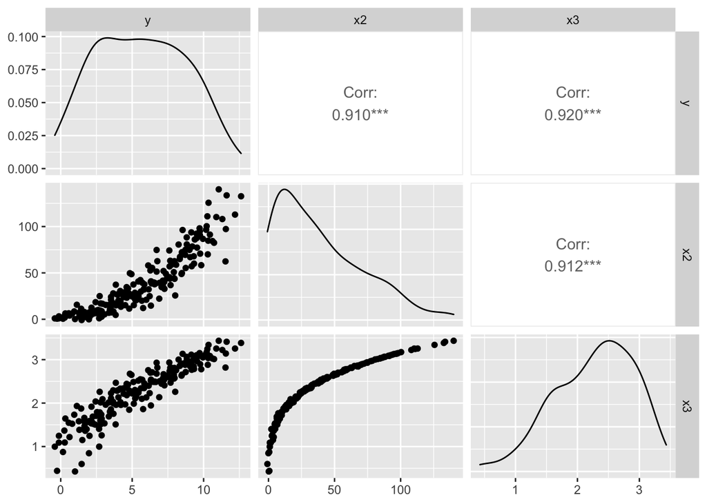

```r
transformdata = read.csv("../Datasets/Transform_V2.txt", sep = "\t")

ggpairs(transformdata[,c(1,3,4)])
```

From the above plot, we could improve the linearity of y and x2 by transforming x2.

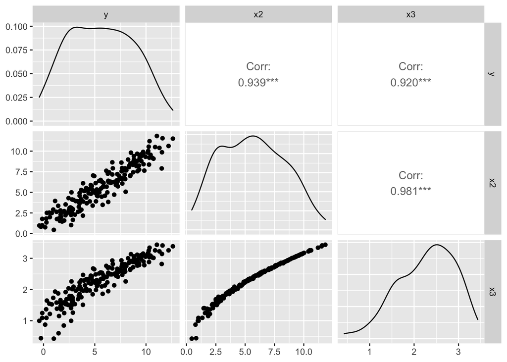

```r
transformdata2 = transformdata
transformdata2$x2 = sqrt(transformdata2$x2)

ggpairs(transformdata2[,c(1,3,4)])
```

Transforming x2 by apply a square root improve the linearity of the relationship.

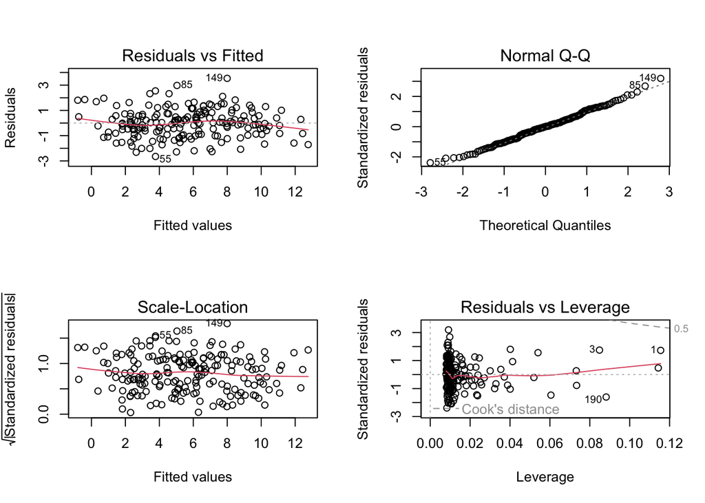

Diagnostic Plots for Original Linear Model

```r
model_t1 = lm(y ~ x2 + x3, transformdata)
par(mfrow = c(2,2))
plot(model_t1)
```

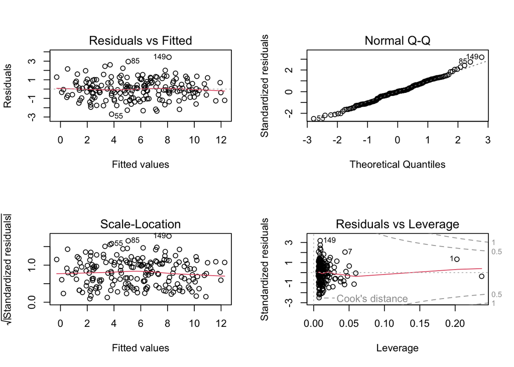

Diagnostic Plot for Transformed Linear Model

```r
model_t2 = lm(y ~ x2 + x3, transformdata2)
par(mfrow = c(2,2))
plot(model_t2)
```

We see that this transformation also improved the variance of the residuals.

5. Given the response variable $y$ and the covariates $x1$ and $x2$ in the dataset *Transform2_V2.txt* data set, check if is necessary to transform any variable and the residual graphs to show that the transformed model is correct.

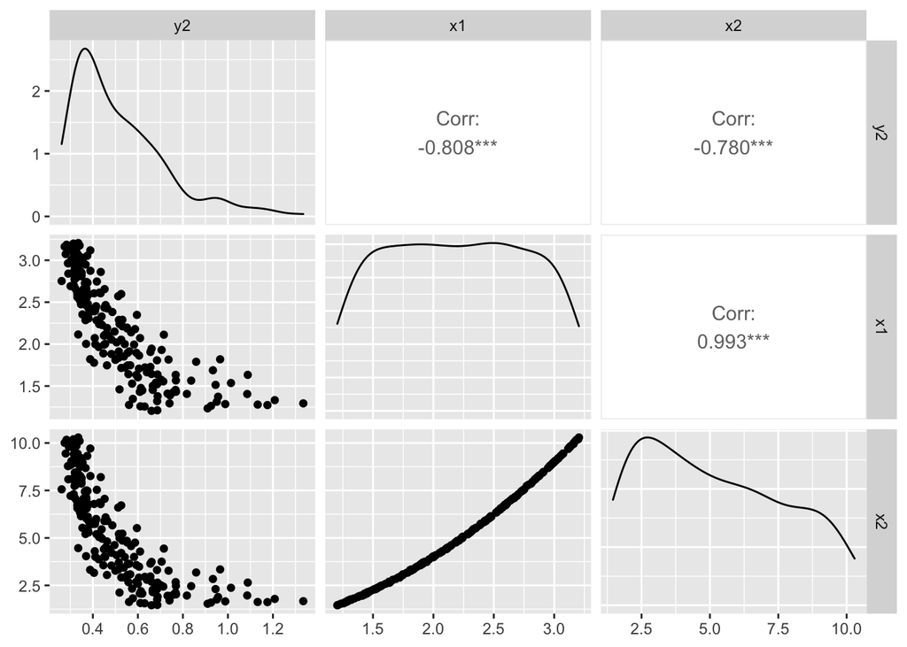

```r
transformdata = read.csv("../Datasets/Transform2_V2.txt", sep = "\t")

ggpairs(transformdata)
```

We can improve the linearity of both relationships (y ~ x1, y ~ x2). For this we’ll use the boxcox method.

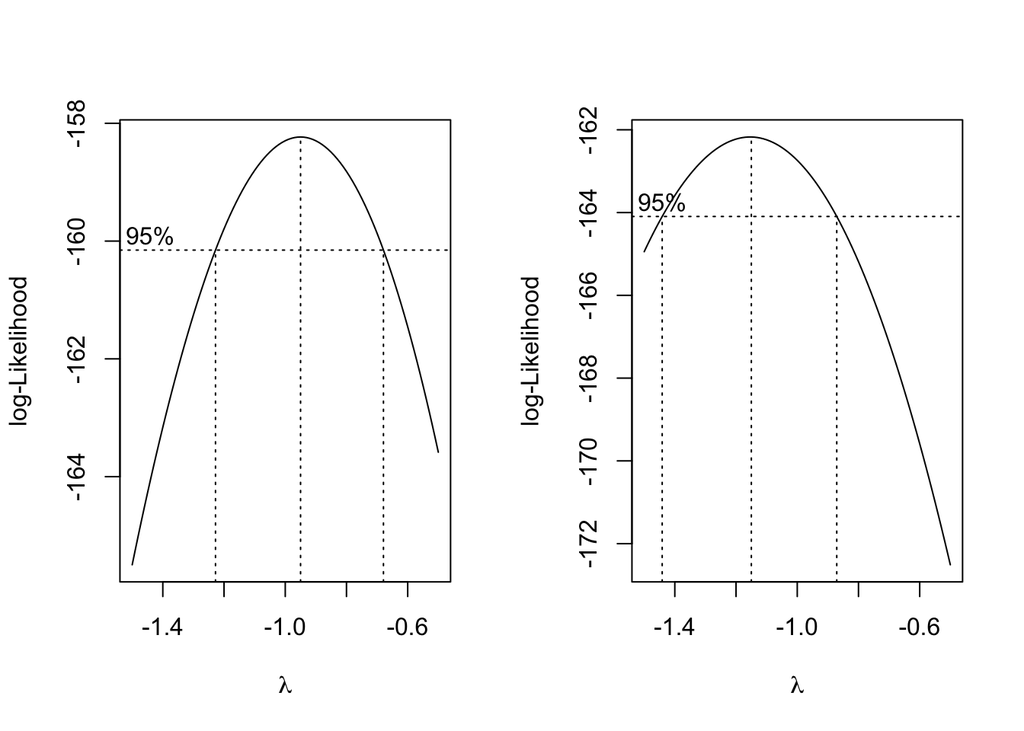

```r
par(mfrow = c(1,2))
transformdata2 = transformdata

boxcox(lm(y2 ~ x1, transformdata2), lambda = seq(-1.5,-0.5, 0.01))
boxcox(lm(y2 ~ x2, transformdata2), lambda = seq(-1.5,-0.5, 0.01))
```

From the plots above we get that the best possible $\lambda$ for both is near -1.

So we transform both variables as follows,

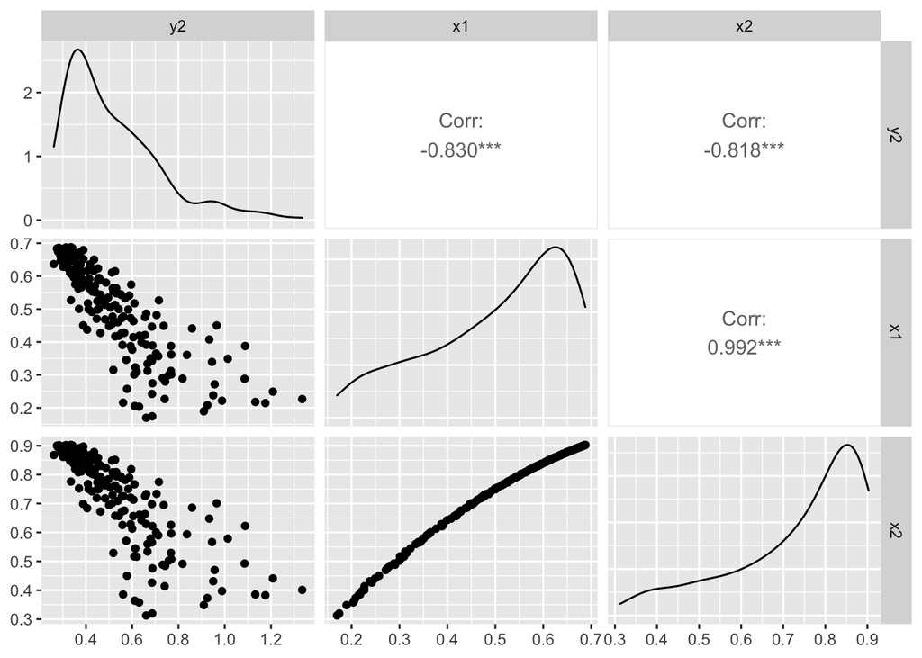

```r
transformdata2 = transformdata
transformdata2$x1 = (transformdata2$x1^(-1) - 1)/(-1)
transformdata2$x2 = (transformdata2$x2^(-1) - 1)/(-1)

ggpairs(transformdata2)
```

Comparing to the previous plots, there is an improvement in the linearty of both relationships.

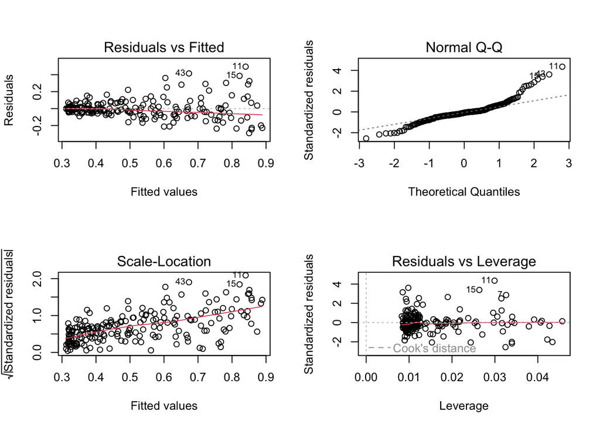

Diagnostic Plots for Original Linear Model

```r
model_t1 = lm(y2 ~ x1 + x2, transformdata)
par(mfrow = c(2,2))
plot(model_t1)
```

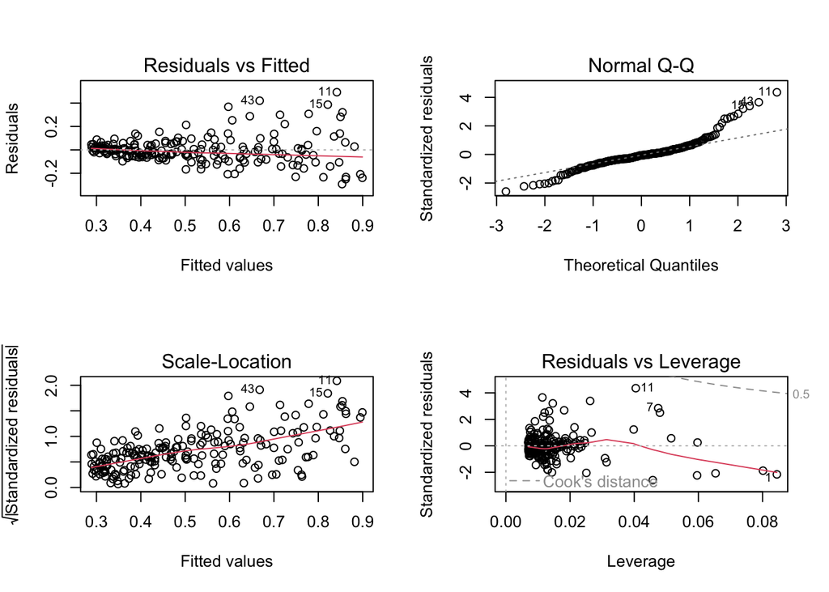

Diagnostic Plot for Transformed Linear Model

```r
model_t2 = lm(y2 ~ x1 + x2, transformdata2)
par(mfrow = c(2,2))
plot(model_t2)
```

7. Calculate the value of $R^{2}$ and $R^{2}_{a}$ for model *fit.ridge* and compare them with the result of *modall* (modall = lm(hwfat ~ .))

```r
library(glmnet)
x = model.matrix(hwfat ~ .-1, bodyfat)
fit.ridge = glmnet(x, bodyfat$hwfat, alpha = 0)
cv.out = cv.glmnet(x, bodyfat$hwfat, alpha = 0)

lambda_opt = cv.out$lambda.min
predicted = predict(fit.ridge, s = lambda_opt, newx= x)


SSE = sum((predicted - bodyfat$hwfat)^2)
SST = sum((bodyfat$hwfat - mean(bodyfat$hwfat))^2)
n = nrow(bodyfat)
k = ncol(bodyfat)

ridge_rsquared = 1 - SSE/SST
ridge_adj_rsquared = 1 - (SSE/(n-k-1))/(SST/(n-1))

ridge_rsquared
```

```
## [1] 0.887387
```

```r
ridge_adj_rsquared
```

```
## [1] 0.8761257
```

```r
modall = lm(hwfat ~ ., bodyfat)
summary(modall)$r.squared
```

```
## [1] 0.8918125
```

```r
summary(modall)$adj.r.squared
```

```
## [1] 0.8826699
```

When comparing both set of values for the model, we can see that both are larger for the linear model.

$$R^{2}_{lm} > R^{2}_{ridge}$$
$$R^{2}_{a-lm} > R^{2}_{a-ridge}$$

8. The dataset *insurance.csv* contains data of insurance premiums paid by people in USA depending on their personal characteristics.
1. Find the model that give the best prediction (take into account that interactions between variables may be present)
2. What is the profile of the people that pay more (or less) for their insurance?

## Barckwards Selection

```r
modall = lm(charges ~ . + age:sex + age:bmi + age:children + age:smoker + age:region + sex:bmi + sex:children + sex:smoker + sex:region + bmi:children + bmi:smoker + bmi:region + children:smoker + children:region + smoker:region, insurance)
drop1(modall, test = "F")
```

```
## Single term deletions
##
## Model:
## charges ~ age + sex + bmi + children + smoker + region + age:sex +
##     age:bmi + age:children + age:smoker + age:region + sex:bmi +
##     sex:children + sex:smoker + sex:region + bmi:children + bmi:smoker +
##     bmi:region + children:smoker + children:region + smoker:region
##                 Df Sum of Sq    RSS     AIC  F value    Pr(>F)
## <none>                       180.59 -2611.6
## age:sex          1     1.466 182.06 -2602.8  10.5889 0.0011668 **
## age:bmi          1     0.376 180.97 -2610.8   2.7141 0.0997043 .
## age:children     1     5.567 186.16 -2573.0  40.1993 3.154e-10 ***
## age:smoker       1    43.789 224.38 -2323.1 316.1834 < 2.2e-16 ***
## age:region       3     2.929 183.52 -2596.1   7.0499 0.0001059 ***
## sex:bmi          1     0.101 180.69 -2612.8   0.7287 0.3934582
## sex:children     1     0.007 180.60 -2613.5   0.0538 0.8165912
## sex:smoker       1     0.448 181.04 -2610.3   3.2363 0.0722559 .
## sex:region       3     0.150 180.74 -2616.5   0.3622 0.7803189
## bmi:children     1     0.000 180.59 -2613.6   0.0001 0.9912549
## bmi:smoker       1    18.367 198.96 -2484.0 132.6190 < 2.2e-16 ***
## bmi:region       3     1.489 182.08 -2606.6   3.5828 0.0134113 *
## children:smoker  1     4.561 185.15 -2580.2  32.9348 1.184e-08 ***
## children:region  3     0.577 181.17 -2613.3   1.3888 0.2445531
## smoker:region    3     0.861 181.45 -2611.2   2.0725 0.1020449
## ---
## Signif. codes:  0 '***' 0.001 '**' 0.01 '*' 0.05 '.' 0.1 ' ' 1
```

```r
newmod = update(modall, . ~ . - bmi:children)
drop1(newmod, test = "F")
```

```
## Single term deletions
##
## Model:
## charges ~ age + sex + bmi + children + smoker + region + age:sex +
##     age:bmi + age:children + age:smoker + age:region + sex:bmi +
##     sex:children + sex:smoker + sex:region + bmi:smoker + bmi:region +
##     children:smoker + children:region + smoker:region
##                 Df Sum of Sq    RSS     AIC  F value    Pr(>F)
## <none>                       180.59 -2613.6
## age:sex          1     1.467 182.06 -2604.8  10.6010  0.001159 **
## age:bmi          1     0.376 180.97 -2612.8   2.7194  0.099379 .
## age:children     1     5.648 186.24 -2574.4  40.8115 2.327e-10 ***
## age:smoker       1    43.803 224.40 -2325.0 316.5296 < 2.2e-16 ***
## age:region       3     2.932 183.52 -2598.1   7.0625  0.000104 ***
## sex:bmi          1     0.101 180.69 -2614.8   0.7292  0.393312
## sex:children     1     0.007 180.60 -2615.5   0.0539  0.816402
## sex:smoker       1     0.449 181.04 -2612.3   3.2463  0.071817 .
## sex:region       3     0.151 180.74 -2618.5   0.3627  0.779929
## bmi:smoker       1    18.451 199.04 -2485.4 133.3315 < 2.2e-16 ***
## bmi:region       3     1.489 182.08 -2608.6   3.5856  0.013361 *
## children:smoker  1     4.574 185.17 -2582.1  33.0541 1.115e-08 ***
## children:region  3     0.580 181.17 -2615.3   1.3962  0.242307
## smoker:region    3     0.863 181.46 -2613.2   2.0790  0.101183
## ---
## Signif. codes:  0 '***' 0.001 '**' 0.01 '*' 0.05 '.' 0.1 ' ' 1
```

```r
newmod = update(newmod, . ~ . - sex:children)
drop1(newmod, test = "F")
```

```
## Single term deletions
##
## Model:
## charges ~ age + sex + bmi + children + smoker + region + age:sex +
##     age:bmi + age:children + age:smoker + age:region + sex:bmi +
##     sex:smoker + sex:region + bmi:smoker + bmi:region + children:smoker +
##     children:region + smoker:region
##                 Df Sum of Sq    RSS     AIC  F value    Pr(>F)
## <none>                       180.60 -2615.5
## age:sex          1     1.479 182.08 -2606.6  10.6970 0.0011011 **
## age:bmi          1     0.379 180.98 -2614.7   2.7415 0.0980141 .
## age:children     1     5.699 186.30 -2576.0  41.2146 1.905e-10 ***
## age:smoker       1    43.796 224.40 -2327.0 316.7062 < 2.2e-16 ***
## age:region       3     2.938 183.54 -2599.9   7.0824 0.0001011 ***
## sex:bmi          1     0.101 180.70 -2616.8   0.7331 0.3920471
## sex:smoker       1     0.450 181.05 -2614.2   3.2526 0.0715421 .
## sex:region       3     0.152 180.75 -2620.4   0.3673 0.7766326
## bmi:smoker       1    18.526 199.13 -2486.9 133.9696 < 2.2e-16 ***
## bmi:region       3     1.491 182.09 -2610.5   3.5937 0.0132117 *
## children:smoker  1     4.570 185.17 -2584.1  33.0497 1.117e-08 ***
## children:region  3     0.577 181.18 -2617.3   1.3909 0.2439213
## smoker:region    3     0.867 181.47 -2615.1   2.0896 0.0997872 .
## ---
## Signif. codes:  0 '***' 0.001 '**' 0.01 '*' 0.05 '.' 0.1 ' ' 1
```

```r
newmod = update(newmod, . ~ . - sex:region)
drop1(newmod, test = "F")
```

```
## Single term deletions
##
## Model:
## charges ~ age + sex + bmi + children + smoker + region + age:sex +
##     age:bmi + age:children + age:smoker + age:region + sex:bmi +
##     sex:smoker + bmi:smoker + bmi:region + children:smoker +
##     children:region + smoker:region
##                 Df Sum of Sq    RSS     AIC  F value    Pr(>F)
## <none>                       180.75 -2620.4
## age:sex          1     1.486 182.24 -2611.5  10.7628 0.0010629 **
## age:bmi          1     0.364 181.12 -2619.7   2.6391 0.1045013
## age:children     1     5.623 186.38 -2581.4  40.7183 2.434e-10 ***
## age:smoker       1    43.843 224.59 -2331.8 317.5062 < 2.2e-16 ***
## age:region       3     2.935 183.69 -2604.9   7.0840 0.0001009 ***
## sex:bmi          1     0.087 180.84 -2621.8   0.6270 0.4285918
## sex:smoker       1     0.438 181.19 -2619.2   3.1692 0.0752689 .
## bmi:smoker       1    18.634 199.39 -2491.1 134.9456 < 2.2e-16 ***
## bmi:region       3     1.497 182.25 -2615.4   3.6148 0.0128350 *
## children:smoker  1     4.477 185.23 -2589.7  32.4225 1.530e-08 ***
## children:region  3     0.584 181.34 -2622.1   1.4108 0.2379399
## smoker:region    3     0.859 181.61 -2620.1   2.0728 0.1020048
## ---
## Signif. codes:  0 '***' 0.001 '**' 0.01 '*' 0.05 '.' 0.1 ' ' 1
```

```r
newmod = update(newmod, . ~ . - sex:bmi)
drop1(newmod, test = "F")
```

```
## Single term deletions
##
## Model:
## charges ~ age + sex + bmi + children + smoker + region + age:sex +
##     age:bmi + age:children + age:smoker + age:region + sex:smoker +
##     bmi:smoker + bmi:region + children:smoker + children:region +
##     smoker:region
##                 Df Sum of Sq    RSS     AIC  F value    Pr(>F)
## <none>                       180.84 -2621.8
## age:sex          1     1.592 182.43 -2612.0  11.5339 0.0007039 ***
## age:bmi          1     0.378 181.22 -2621.0   2.7362 0.0983400 .
## age:children     1     5.656 186.50 -2582.6  40.9732 2.145e-10 ***
## age:smoker       1    44.087 224.93 -2331.9 319.3656 < 2.2e-16 ***
## age:region       3     2.904 183.74 -2606.5   7.0127 0.0001116 ***
## sex:smoker       1     0.435 181.27 -2620.6   3.1501 0.0761558 .
## bmi:smoker       1    18.663 199.50 -2492.4 135.1984 < 2.2e-16 ***
## bmi:region       3     1.432 182.27 -2617.2   3.4578 0.0159131 *
## children:smoker  1     4.431 185.27 -2591.4  32.0963 1.802e-08 ***
## children:region  3     0.591 181.43 -2623.4   1.4263 0.2334040
## smoker:region    3     0.845 181.68 -2621.5   2.0397 0.1065059
## ---
## Signif. codes:  0 '***' 0.001 '**' 0.01 '*' 0.05 '.' 0.1 ' ' 1
```

```r
newmod = update(newmod, . ~ . - children:region)
drop1(newmod, test = "F")
```

```
## Single term deletions
##
## Model:
## charges ~ age + sex + bmi + children + smoker + region + age:sex +
##     age:bmi + age:children + age:smoker + age:region + sex:smoker +
##     bmi:smoker + bmi:region + children:smoker + smoker:region
##                 Df Sum of Sq    RSS     AIC  F value    Pr(>F)
## <none>                       181.43 -2623.4
## age:sex          1     1.655 183.08 -2613.3  11.9739 0.0005568 ***
## age:bmi          1     0.335 181.76 -2622.9   2.4230 0.1198054
## age:children     1     5.503 186.93 -2585.4  39.8257 3.789e-10 ***
## age:smoker       1    44.453 225.88 -2332.2 321.7078 < 2.2e-16 ***
## age:region       3     2.872 184.30 -2608.4   6.9283 0.0001257 ***
## sex:smoker       1     0.468 181.90 -2622.0   3.3902 0.0658097 .
## bmi:smoker       1    18.865 200.29 -2493.1 136.5254 < 2.2e-16 ***
## bmi:region       3     1.446 182.88 -2618.8   3.4889 0.0152484 *
## children:smoker  1     4.390 185.82 -2593.4  31.7698 2.122e-08 ***
## smoker:region    3     0.818 182.25 -2623.4   1.9743 0.1159799
## ---
## Signif. codes:  0 '***' 0.001 '**' 0.01 '*' 0.05 '.' 0.1 ' ' 1
```

```r
newmod = update(newmod, . ~ . - smoker:region)
drop1(newmod, test = "F")
```

```
## Single term deletions
##
## Model:
## charges ~ age + sex + bmi + children + smoker + region + age:sex +
##     age:bmi + age:children + age:smoker + age:region + sex:smoker +
##     bmi:smoker + bmi:region + children:smoker
##                 Df Sum of Sq    RSS     AIC  F value    Pr(>F)
## <none>                       182.25 -2623.4
## age:sex          1     1.634 183.88 -2613.4  11.7967 0.0006118 ***
## age:bmi          1     0.357 182.60 -2622.8   2.5750 0.1088037
## age:children     1     5.533 187.78 -2585.4  39.9566 3.548e-10 ***
## age:smoker       1    45.410 227.66 -2327.7 327.9009 < 2.2e-16 ***
## age:region       3     2.743 184.99 -2609.4   6.6033 0.0001987 ***
## sex:smoker       1     0.501 182.75 -2621.7   3.6178 0.0573841 .
## bmi:smoker       1    21.585 203.83 -2475.6 155.8647 < 2.2e-16 ***
## bmi:region       3     1.510 183.76 -2618.3   3.6351 0.0124818 *
## children:smoker  1     4.256 186.50 -2594.5  30.7328 3.574e-08 ***
## ---
## Signif. codes:  0 '***' 0.001 '**' 0.01 '*' 0.05 '.' 0.1 ' ' 1
```

```r
newmod = update(newmod, . ~ . - age:bmi)
drop1(newmod, test = "F")
```

```
## Single term deletions
##
## Model:
## charges ~ age + sex + bmi + children + smoker + region + age:sex +
##     age:children + age:smoker + age:region + sex:smoker + bmi:smoker +
##     bmi:region + children:smoker
##                 Df Sum of Sq    RSS     AIC  F value    Pr(>F)
## <none>                       182.60 -2622.8
## age:sex          1     1.583 184.19 -2613.2  11.4151 0.0007498 ***
## age:children     1     5.622 188.23 -2584.2  40.5472 2.645e-10 ***
## age:smoker       1    45.392 228.00 -2327.7 327.3845 < 2.2e-16 ***
## age:region       3     2.435 185.04 -2611.1   5.8540 0.0005703 ***
## sex:smoker       1     0.539 183.14 -2620.8   3.8892 0.0488052 *
## bmi:smoker       1    21.772 204.38 -2474.1 157.0296 < 2.2e-16 ***
## bmi:region       3     1.530 184.13 -2617.6   3.6778 0.0117713 *
## children:smoker  1     4.325 186.93 -2593.4  31.1905 2.838e-08 ***
## ---
## Signif. codes:  0 '***' 0.001 '**' 0.01 '*' 0.05 '.' 0.1 ' ' 1
```

```r
newmod = update(newmod, . ~ . - region)
drop1(newmod, test = "F")
```

```
## Single term deletions
##
## Model:
## charges ~ age + sex + bmi + children + smoker + age:sex + age:children +
##     age:smoker + age:region + sex:smoker + bmi:smoker + bmi:region +
##     children:smoker
##                 Df Sum of Sq    RSS     AIC  F value    Pr(>F)
## <none>                       182.97 -2626.1
## age:sex          1     1.547 184.52 -2616.8  11.1587 0.0008598 ***
## age:children     1     5.653 188.63 -2587.4  40.7806 2.354e-10 ***
## age:smoker       1    45.493 228.47 -2331.0 328.1940 < 2.2e-16 ***
## age:region       3     2.731 185.70 -2612.2   6.5664 0.0002093 ***
## sex:smoker       1     0.527 183.50 -2624.2   3.7999 0.0514666 .
## bmi:smoker       1    21.622 204.60 -2478.6 155.9841 < 2.2e-16 ***
## bmi:region       3     5.703 188.68 -2591.0  13.7147 8.221e-09 ***
## children:smoker  1     4.390 187.36 -2596.3  31.6735 2.225e-08 ***
## ---
## Signif. codes:  0 '***' 0.001 '**' 0.01 '*' 0.05 '.' 0.1 ' ' 1
```

```r
newmod = update(newmod, . ~ . - sex:smoker)
drop1(newmod, test = "F")
```

```
## Single term deletions
##
## Model:
## charges ~ age + sex + bmi + children + smoker + age:sex + age:children +
##     age:smoker + age:region + bmi:smoker + bmi:region + children:smoker
##                 Df Sum of Sq    RSS     AIC  F value    Pr(>F)
## <none>                       183.50 -2624.2
## age:sex          1     1.511 185.01 -2615.2  10.8791 0.0009984 ***
## age:children     1     5.574 189.07 -2586.2  40.1285 3.254e-10 ***
## age:smoker       1    45.746 229.25 -2328.4 329.3176 < 2.2e-16 ***
## age:region       3     2.808 186.31 -2609.9   6.7389 0.0001641 ***
## bmi:smoker       1    22.838 206.34 -2469.3 164.4098 < 2.2e-16 ***
## bmi:region       3     5.800 189.30 -2588.6  13.9175 6.162e-09 ***
## children:smoker  1     4.201 187.70 -2595.9  30.2414 4.575e-08 ***
## ---
## Signif. codes:  0 '***' 0.001 '**' 0.01 '*' 0.05 '.' 0.1 ' ' 1
```

```r
options(scipen = 10)
summary(newmod)
```

```
##
## Call:
## lm(formula = charges ~ age + sex + bmi + children + smoker +
##     age:sex + age:children + age:smoker + age:region + bmi:smoker +
##     bmi:region + children:smoker, data = insurance)
##
## Residuals:
##      Min       1Q   Median       3Q      Max
## -0.59056 -0.15404 -0.08062 -0.01502  2.51081
##
## Coefficients:
##                       Estimate Std. Error t value       Pr(>|t|)
## (Intercept)          6.9776225  0.0763608  91.377        < 2e-16 ***
## age                  0.0380778  0.0016825  22.631        < 2e-16 ***
## sexmale             -0.2736375  0.0607484  -4.504 0.000007242453 ***
## bmi                  0.0102663  0.0026285   3.906 0.000098687501 ***
## children             0.2899849  0.0272299  10.650        < 2e-16 ***
## smokeryes            1.3757185  0.1423715   9.663        < 2e-16 ***
## age:sexmale          0.0048086  0.0014579   3.298       0.000998 ***
## age:children        -0.0041034  0.0006478  -6.335 0.000000000325 ***
## age:smokeryes       -0.0333083  0.0018355 -18.147        < 2e-16 ***
## age:regionnorthwest  0.0026216  0.0019582   1.339       0.180875
## age:regionsoutheast  0.0075608  0.0018641   4.056 0.000052829477 ***
## age:regionsouthwest  0.0064799  0.0020083   3.227       0.001283 **
## bmi:smokeryes        0.0522072  0.0040716  12.822        < 2e-16 ***
## bmi:regionnorthwest -0.0054974  0.0027461  -2.002       0.045496 *
## bmi:regionsoutheast -0.0142689  0.0024717  -5.773 0.000000009698 ***
## bmi:regionsouthwest -0.0134660  0.0027530  -4.891 0.000001124678 ***
## children:smokeryes  -0.1198444  0.0217930  -5.499 0.000000045747 ***
## ---
## Signif. codes:  0 '***' 0.001 '**' 0.01 '*' 0.05 '.' 0.1 ' ' 1
##
## Residual standard error: 0.3727 on 1321 degrees of freedom
## Multiple R-squared:  0.8377, Adjusted R-squared:  0.8357
## F-statistic: 426.1 on 16 and 1321 DF,  p-value: < 2.2e-16
```

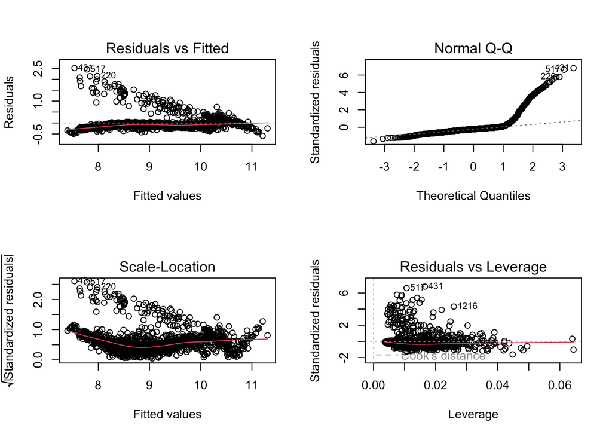

```r
par(mfrow = c(2,2))
plot(newmod)
```

*Note: All this coefficients must be interpreted taking into account that the response variable was logged transformed at the beggining of the procedure.

Profile of people who pay more: - The older you are, the more you pay. - Females pay more than males (~23%). - Every child adds a 33% increase in your charges. - Smokers also pay more.